# SLE Risk Probability Index (SLERPI)

Christopher McMaster

19/02/2021

# Mathematics

## Ordinary Least Squares (OLS) Regression

We estimate outcomes using regression, but how do we obtain coefficients 𝛽?

$$\hat{y}=\beta_0 + \beta_1 x$$

The most common approach uses OLS, a method where the coefficients are obtained by finding the values that results in the *least square error*:

$$RSS=\sum_{1=1}^{n}(y_i -(\hat{\beta_0}+\hat{\beta_1}x_i))^2$$

## LASSO Regression

$$RSS=\sum_{1=1}^{n}(y_i -(\hat{\beta_0}+\hat{\beta_1}x_i))^2 + \lambda|\beta_1|$$

# Iris Dataset

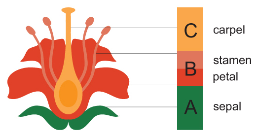

| Sepal Length | Sepal Width | Petal Length | Petal Width | Species |
| --- | --- | --- | --- | --- |
| 5.1 | 3.5 | 1.4 | 0.2 | setosa |
| 4.9 | 3.0 | 1.4 | 0.2 | setosa |
| 4.7 | 3.2 | 1.3 | 0.2 | setosa |
| 4.6 | 3.1 | 1.5 | 0.2 | setosa |
| 5.0 | 3.6 | 1.4 | 0.2 | setosa |
| 5.4 | 3.9 | 1.7 | 0.4 | setosa |

# Iris Dataset

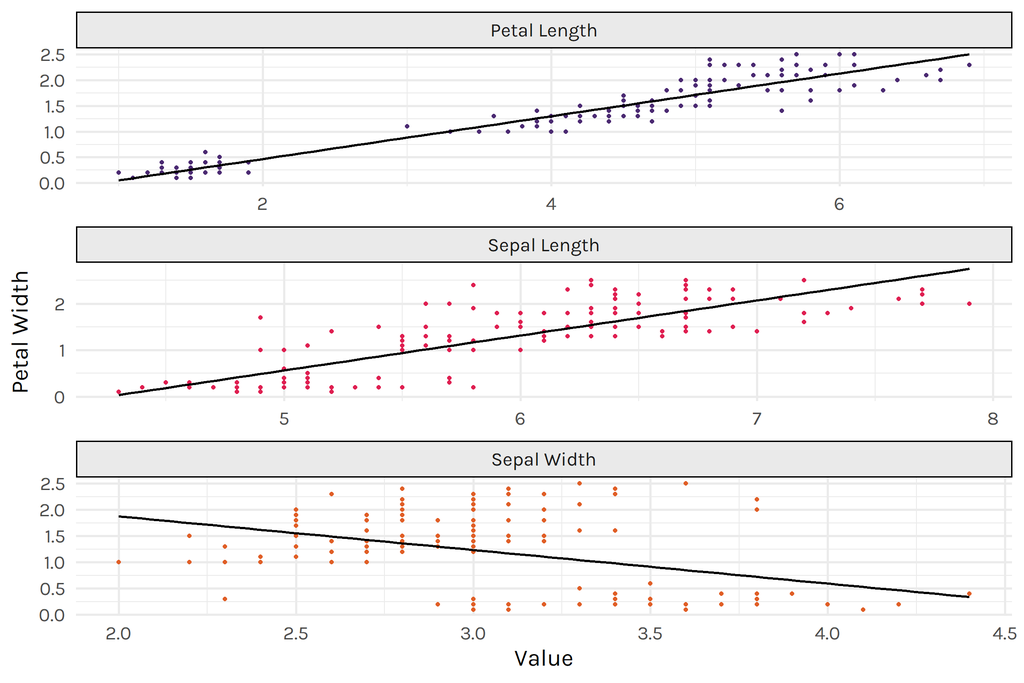

# LASSO

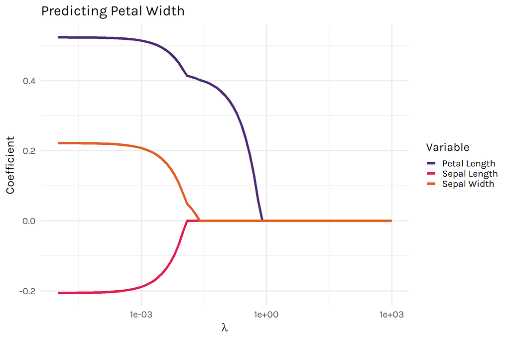

# LASSO

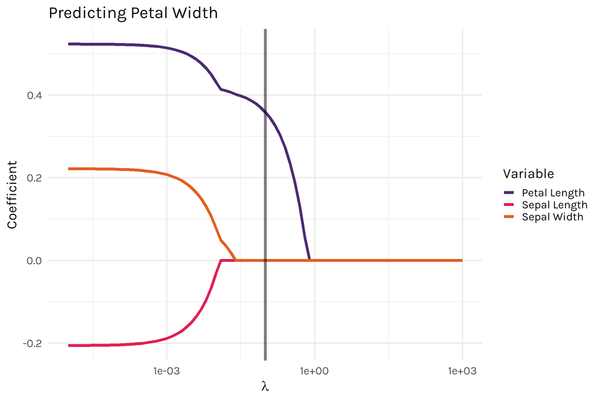

# **Lupus or not? SLE Risk Probability Index (SLERPI): a simple, clinician-friendly machine learning-based model to assist the diagnosis of systemic lupus erythematosus**

**Rationale:** we have several classification criteria for SLE, but no diagnostic criteria.  
Maybe “machine learning” can help ¯\_(ツ)_/¯

# Setting

Pooled data from two hospitals in **Greece** with established SLE registries.

[figure not shown]

# Data

## Collection

Algorithm Development

Algorithm Validation

Patients diagnosed between 01/2005 – 06/2019 with SLE or other rheumatic disease (control).

Prospective collection of data for patients diagnosed with SLE or other rheumatic disease (control)

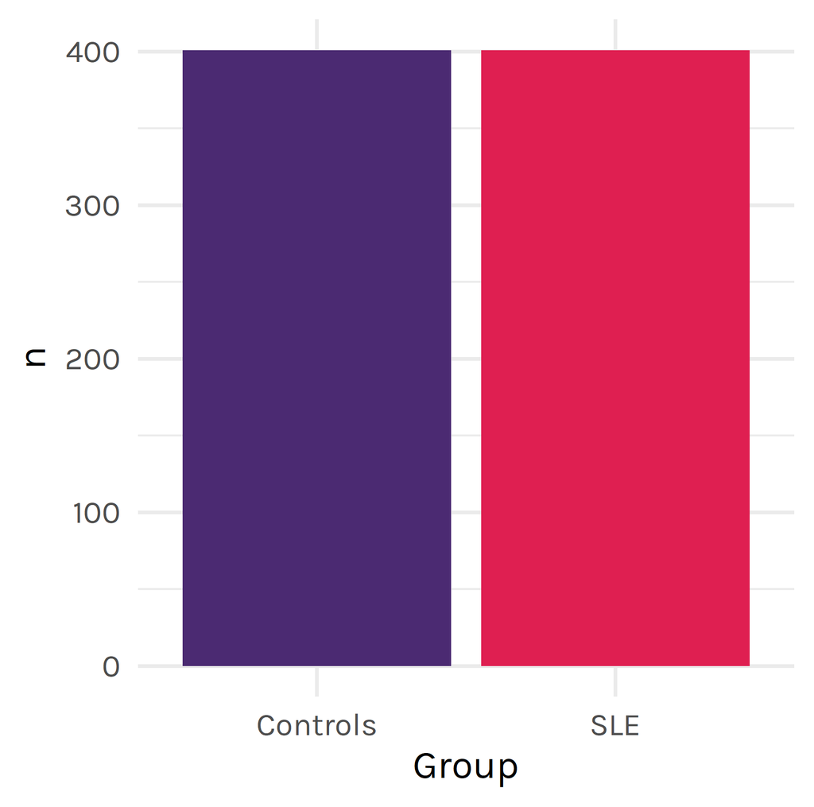

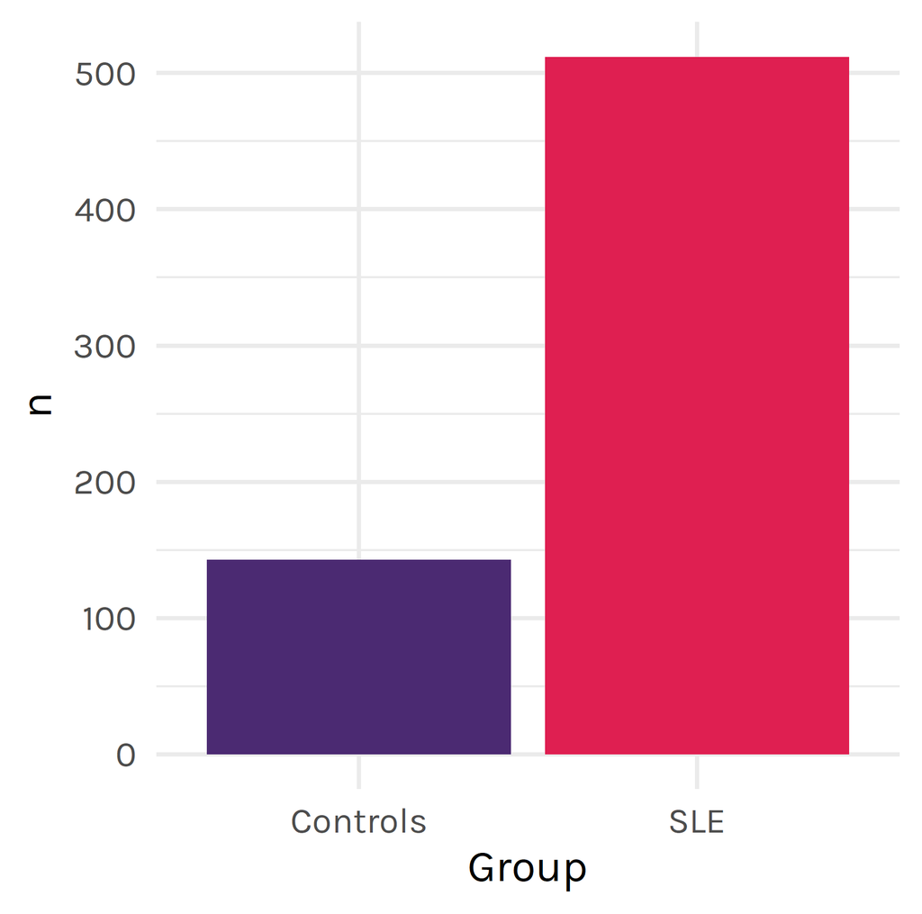

# Data

## Variables

- Demographics
- All elements of three classification criteria (ACR 1997, SLICC 2012, EULAR/ACR 2019)
- Extra data points at their discretion

# Data

| ACR97 malar | SLICC Alopecia | SLICC clinical criteria | Neuro score | Hypocompl score | enteropathy |
| --- | --- | --- | --- | --- | --- |
| ACR97 discoid | SLICC Ulcers | SLICC immun criteria | EULAR serositis A | EULAR spec autoAbs | pneumonitis |
| ACR97 photosens | SLICC Serositis | SLICC criteria fulfil | EULAR serositis B | Autoabs score | ILD |
| ACR97 ulcers | SLICC Renal | SLICC classified criteria | Serositis score | EULAR ACR score | alv hemorrhage |
| ACR97 synovitis | SLICC CNS | EULAR fever | EULAR hem A | EULAR ACR classified | TTP |
| ACR97 serositis | SLICC AIHA | Fever score | EULAR hem B | fatigue | Splenomegaly |
| ACR97 renal | SLICC Leucopenia | EULAR cut A | Hem score | lymphaden | epi scleritis |
| ACR97 neurol | SLICC Thrombocytopenia | EULAR cut B | EULAR renal A | sicca | uveitis |
| ACR97 hematol | SLICC aDNA | EULAR cut C | EULAR renal B | dermographism | myocarditis |
| ACR97 immunol | SLICC aSm | Cutaneous score | EULAR renal C | skin vascul | aRNP |
| ACR97 ANA | SLICC aPL | EULAR synovitis | Renal score | livedo | aSSA |
| ACR97 items | SLICC Compl | Synovitis score | EULAR aPL | urticaria | aSSB |
| ACR97 | SLICC Coombs | EULAR neuro A | aPL score | ascites | Raynaud |
| SLICC ACLE | SLICC ANA | EULAR neuro B | EULAR hypocompl A | hepatitis | Myositis |
| SLICC CCLE | SLICC Kidney bx | EULAR neuro C | EULAR hypocompl B | mes vasculit | SLE |

# Methods

[figure not shown]

# Results

## Control Groups

| Disease | Discovery | Validation |
| --- | --- | --- |
| Rheumatoid arthritis | 126 (31%) | 28 (20%) |
| Undifferentiated connective tissue disease | 57 (14%) | 56 (39%) |
| Sjogren’s syndrome | 43 (11%) | 11 (8%) |
| Scleroderma | 42 (10%) | 11 (8%) |
| Psoriatic arthritis | 25 (6%) | 7 (6%) |
| Vasculitis | 22 (5%) | 2 (1%) |
| Behcet’s disease | 17 (4%) | 2 (1%) |
| Myositis | 19 (5%) | 9 (6%) |
| Familial Mediterranean Fever | 18 (4%) | 3 (2%) |
| Adult-onset still’s disease | 14 (3%) | 5 (3%) |
| Fibromyalgia | 3 (1%) | 2 (1%) |
| Primary antiphospholipid syndrome | 9 (2%) | 1 (1%) |
| Chronic cutaneous lupus erythematosus | 6 (1%) | 4 (3%) |

# Results

## Model comparison

| Model | Method | Brief.description/model.features | AUC | ACC | SENS | SPEC |
| --- | --- | --- | --- | --- | --- | --- |
| M1 | LR | ACR-1997 criteria (binary variable) | 89.28 | 89.28 | 85.55 | 93.01 |
| M4 | Lasso-LR | ACR-1997 criteria (binary variable), low C3 or C4, maculopapular rash | 94.90 | 91.76 | 93.27 | 90.26 |
| M5 | RF | ACR-1997 criteria plus all non-redundant features from other criteria and non-criteria features | 95.07 | 91.64 | 93.02 | 90.26 |
| M6 | LR | ACR-1997 criteria (continuous score) | 95.70 | 89.28 | 85.55 | 93.01 |
| M8 | Lasso-LR | ACR-1997 criteria (continuous score), alopecia, low C3 or C4, interstitial lung disease, maculopapular rash | 97.44 | 92.39 | 93.27 | 91.51 |
| M10 | LR | SLICC-2012 (binary variable) | 92.52 | 92.51 | 91.28 | 93.76 |
| M12 | RF | SLICC-2012 (binary variable) plus all non-redundant features from other criteria and non-criteria features | 95.84 | 93.26 | 92.52 | 94.01 |
| M13 | LR | SLICC-2012 (continuous clinical and immunological scores) | 97.34 | 92.51 | 94.26 | 90.76 |
| M15 | Lasso-LR | SLICC-2012 (continuous clinical and immunological scores), lymphopenia <1000/?L | 97.61 | 92.89 | 93.51 | 92.26 |
| M17 | LR | EULAR/ACR-2019 (binary model) | 92.27 | 92.27 | 87.29 | 97.26 |
| M20 | Lasso-LR | EULAR/ACR-2019 (binary model), photosensitivity, myositis, chronic CLE other than DLE | 96.09 | 92.77 | 88.04 | 97.51 |
| M22 | LR | EULAR/ACR-2019 (continuous score), ANA | 96.95 | 91.89 | 90.53 | 93.26 |
| M25 | Lasso-LR | EULAR/ACR-2019 (continuous score), ANA, livedo reticularis, interstitial lung disease | 97.40 | 93.26 | 92.53 | 94.01 |
| M26 | RF | EULAR/ACR-2019 (continuous score), ANA plus all nonredundant features from other criteria and non-criteria features | 97.90 | 92.89 | 91.28 | 94.51 |
| M31 | Lasso-LR | De novo model including: mucosal ulcers, synovitis, serositis, immunologic disorder (modified), ANA, alopecia, neurological disorder, malar/maculopapular rash, SCLE or DLE, leucopenia, thrombocytopeni… | 98.32 | 95.02 | 94.53 | 95.51 |

# Final Model - Variables

[output not shown]

# Final Model - Validation

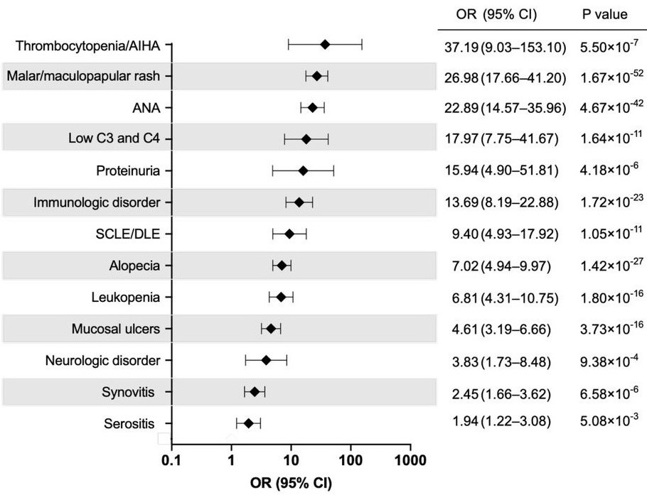

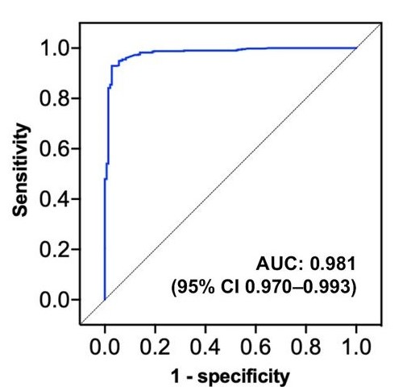

# Final Model - Cutpoint Performance

| Subgroup | Sensitivity |
| --- | --- |
| Early SLE (n=276) | 0.928 |
| LN (n=48) | 0.979 |
| NPL (n=61) | 0.918 |
| Haem (n=74) | 0.986 |
| Severe (n=110) | 0.964 |

| Prediction | Actual SLE | Actual Not SLE |
| --- | --- | --- |
| SLE | 487 | 9 |
| Not SLE | 25 | 134 |

# Criticisms of the Method

[figure not shown]

# Criticisms of the Method

[figure not shown]

# Criticisms of the Cohort

## Who were these patients?

- Patients with **established SLE**, in a registry.
- These were **not patients** captured at the point when a clinician was attempting to **answer the question: is this SLE?**

## Early SLE

- More than half the validation cohort.
- Early? Maybe.
- Established? Definitely - by definition they had to have a well-established diagnosis to enter into a lupus registry

# Criticisms of the Data

## Input data is generated by experts

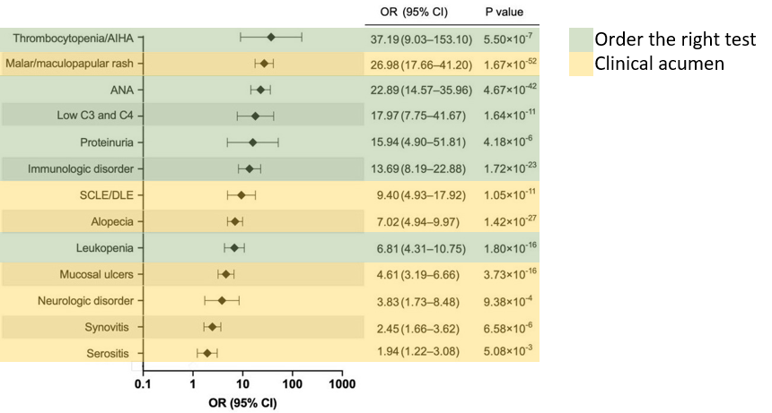

# Criticisms of the Reporting

- Long section on risk thresholds and SLE sorting patients into likelihood groups (e.g. certain SLE, likely, possible, unlikely etc.)
- BUT there was no model calibration

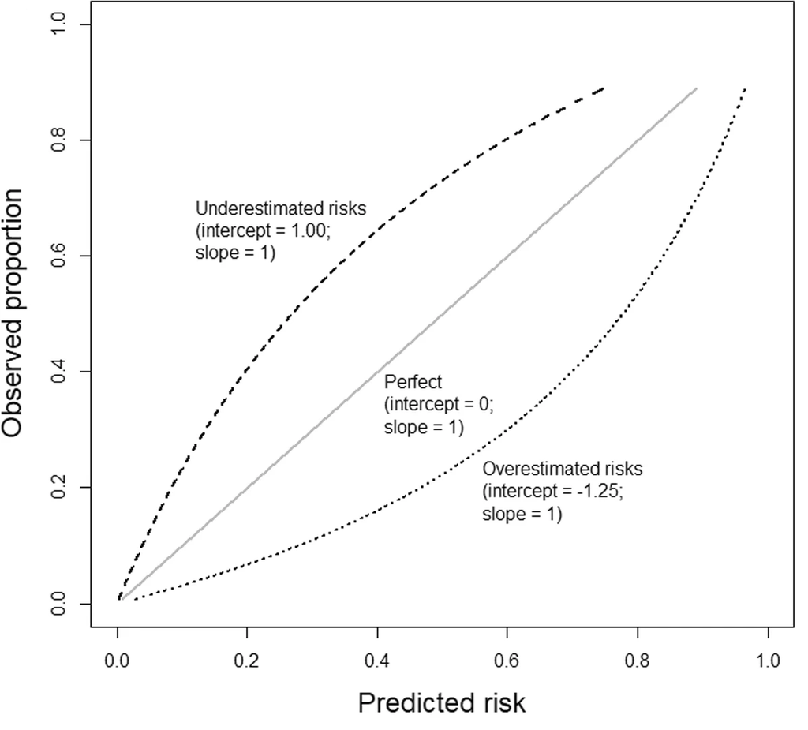

# My Own Research

[figure not shown]

- Working in Rheumatology and Clinical Pharmacology (Medicines Optimisation Service)
- Starting PhD
  - Faculty of Engineering and Information Technology
    - Centre for Digital Transformation of Health (MDHS)
    - Melbourne Centre for Data Science
  - Supervisors
    - Dr Douglas Pires
    - Prof Wendy Chapman
    - A/Prof Russell Buchanan

# My Own Research

[figure not shown]

- Working in Rheumatology and Clinical Pharmacology (Medicines Optimisation Service)
- Starting PhD
  - Research area
    - Multi-model machine learning for prediction & detection
      - Structured EMR data
      - **Text**
      - **Images**
    - Adverse Drug Reactions
      - Detection & prediction
      - Focus on immune-related adverse events (irAEs)
        - Detect, predict, study

McMaster, Christopher, David Liew, Claire Keith, Parnaz Aminian, and Albert Frauman. 2019. “A Machine-Learning Algorithm to Optimise Automated Adverse Drug Reaction Detection from Clinical Coding.” Drug Saf. 42 (6): 721–25. https://doi.org/10.1007/s40264-018-00794-y.